# simulate_map_gcode

System Insights

2019-01-07

# Introduction

This vignette first shows how to obtain simulated device data from G Code. Then, with the help of actual device data available, the simulated and actual data are compared.

```r
library(mtconnectR)
library(ggplot2)
library(dplyr)
file_path_dmtcd = "extdata/data_truncated.bz2"
file_path_xml   = "extdata/Devices.xml"

# Reading MTC Data
device_name = get_device_info_from_xml(system.file(file_path_xml,package = "mtconnectR"))$name[2]
mtc_device = create_mtc_device_from_dmtcd(system.file(file_path_dmtcd,package = "mtconnectR"),     system.file(file_path_xml,package = "mtconnectR"),device_name)
```

```
## Reading Delimted MTC data...
```

```
## 100% data contextualized successfuly!
```

## Calculating feed rate from the position data

This function calculates the feed rate based on the position data and returns the timestamps and the corresponding feed rates

```r
calc_feed = calculated_feed_from_position(mtc_device) %>%
  mutate(value = replace(value, value < 0.1, 0)) %>%
  clean_reduntant_rows()
```

```
## Using Datatems path_pos_x,path_pos_y,path_pos_z for calculating PFR
```

## Adding feed rate data item to MTC Device

This function is very useful to append data to the MTCDevice object A data frame in timestamp|value format along with data item type, name and source type can be added as a data item

```r
mtc_device = add_data_item_to_mtc_device(mtc_device, calc_feed, category = "SAMPLE",
                                         data_item_name = "pfr_calculated<PATH_FEEDRATE>")

# Using merge with regex pattern to choose only the position variables
pos_data_mtc = merge(mtc_device, "path_pos") %>% filter(timestamp > as.POSIXct("2016-03-22"))
names(pos_data_mtc) = extract_param_from_xpath(names(pos_data_mtc), show_warnings = F)
```

## Parse G Code

This is the first step in simulating device data from G Code This function parses the file which has the G code and splits it into blocks of G code and gives contextual information to each block with the help of the inbuilt G code dictionary

```r
gcode_file_path = "extdata/raw_gcode.NC"
gcode_parsed = parse_gcode(system.file(gcode_file_path,package = "mtconnectR"))
```

```
##
## CENTER_POSITION      MOTION_ARC   MOTION_LINEAR    MOTION_RAPID
##             410             170             159              35
##   PATH_FEEDRATE        POSITION
##              69            1404
```

## Simulate G Code data

This function finds the simulated postion and velocity data from the parsed G code

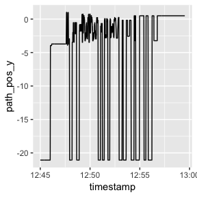

```r
simulated_gcode_data = simulate_data_from_gcode(gcode_parsed, start_time = 0, data_res = 0.1, data_type = "HH") %>%   na.omit()

# Creating MTCDevice object from the simulated data
mtc_device_sim = create_mtc_device_from_ts(simulated_gcode_data)
pos_data_sim = merge(mtc_device_sim, "pos")

# Plotting variation of Y position with time
ggplot(pos_data_mtc) + geom_path(aes(x = timestamp, y = path_pos_y))
```

## Subsetting data for the operation for which we want to compare the simulated and actual data

```r
time_split_start = as.POSIXct("2016-03-22 12:45:00", tz = "UTC")
time_split_end = as.POSIXct("2016-03-22 13:00:00", tz = "UTC")

pos_data_mtc = pos_data_mtc %>% filter(timestamp > time_split_start & timestamp < time_split_end)
```

## A number of plots are made to compare the simulated and actual data

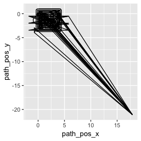

```r
# Plotting Y position vs X position to get an idea of the part made
ggplot(pos_data_mtc) + geom_path(aes(x = path_pos_x, y = path_pos_y))
```

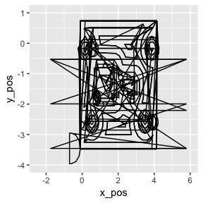

```r
# Plotting simulated part as per proper scale
ggplot(pos_data_sim) + geom_path(aes(x = x_pos, y = y_pos)) +
  coord_cartesian(xlim = c(-2.5, 6), ylim = c(-4, 1))
```

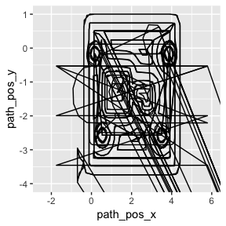

```r
# Plotting actual part as per proper scale
ggplot(pos_data_mtc) + geom_path(aes(x = path_pos_x, y = path_pos_y)) +
  coord_cartesian(xlim = c(-2.5, 6), ylim = c(-4, 1))
```

## Map G Code simulated data to MTC data

This function maps the timestamps of the simulated data to the actual ones by constructing a distance matrix and then using a step pattern to map

```r
time_start_op = as.POSIXct("2016-03-22 12:45:00", tz = "UTC")
time_end_op = as.POSIXct("2016-03-22 13:00:00", tz = "UTC")

mtc_device_op = mtc_device %>% filter_timestamps_mtc_device(time_start_op, time_end_op)
mtc_sim_mapped_op = map_gcode_mtc(mtc_device_sim, mtc_device_op, elasticity = 200)
```

```
## Using the following mapping:
```

```
##   sim_name                                                 mtc_name
## 1    x_pos nist_testbed_GF_Agie_1<Device>:path_pos_x<PATH_POSITION>
## 2    y_pos nist_testbed_GF_Agie_1<Device>:path_pos_y<PATH_POSITION>
## 3    z_pos nist_testbed_GF_Agie_1<Device>:path_pos_z<PATH_POSITION>
```

```
## Normalized Distance: 0.35677295992244
```

## plot_twoway

This function is used to visualise the mapping between the timestamps of the simulated and actual data

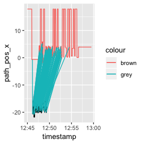

```r
plot_twoway(mtc_sim_mapped_op, mtc_device_sim, mtc_device_op, 20, 100)
```

## Comparing feed parameters

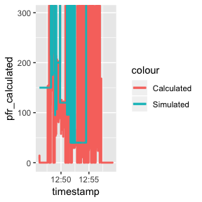

```r
# Comparing feed rate data Simulated vs actual
feed_compare_op = merge(mtc_sim_mapped_op, "pfr") %>% na.omit()
names(feed_compare_op) = extract_param_from_xpath(names(feed_compare_op), show_warnings = F)

ggplot(feed_compare_op, aes(x = timestamp)) +
  geom_step(aes(y = pfr_calculated, colour = 'Calculated'), size = 1) +
  geom_step(aes(y = pfr, colour = "Simulated"), size = 1) +
  coord_cartesian(ylim = c(-3, 300))
```

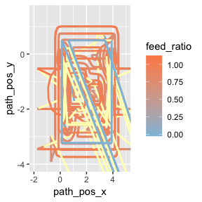

```r
# Comparing feed ratio data Simulated vs actual
pos_feed_ratio_compare_op = merge(mtc_sim_mapped_op, "pfr|_pos_") %>% na.omit()
names(pos_feed_ratio_compare_op) = extract_param_from_xpath(names(pos_feed_ratio_compare_op), show_warnings = F)

pos_feed_ratio_compare_op = pos_feed_ratio_compare_op %>%
  mutate(feed_ratio = abs(round(((pfr_calculated)/(pfr + 1e-6)), 2))) %>%
  mutate(feed_ratio = replace(feed_ratio, feed_ratio > 1.1, NA_real_))

ggplot(pos_feed_ratio_compare_op) +
  geom_path(aes(x = path_pos_x, y = path_pos_y, col = feed_ratio), size = 1) +
  scale_colour_gradient(low="#91bfdb", high = "#fc8d59", na.value = "#ffffbf") +
  coord_cartesian(xlim = c(-2, 5), ylim = c(-4, 1.5))
```